# Introduction to the Command Line (Terminal)

Gepoliano Chaves, Ph. D.

September 9th, 2023

# 0) Git clone GitHub repository in the VM Desktop

- This command should be entered at the terminal in your Virtual Machine.

```bash
git clone https://github.com/gepolianochaves/bioinformatics-bridge-course
```

# 1. Introducing the Shell

print working directory

```bash
pwd
```

```
## /Users/gepolianochaves/Desktop/Gepoliano/SIP2023_BME03/recombio/1-Introduction/scripts
```

list

```bash
ls
```

```
## Introduction to R and Terminal.Rmd
## Introduction to the Terminal.Rmd
## Introduction-to-R-and-Terminal.html
## Introduction-to-the-Terminal.Rmd
## Introduction-to-the-Terminal.html
## test folder
```

# 1. Introducing the Shell (continued)

command not found

```bash
pws
```

# 2. Navigating files and directories

```bash
pwd
```

```
## /Users/gepolianochaves/Desktop/Gepoliano/SIP2023_BME03/recombio/1-Introduction/scripts
```

Indicate directory with slash and file without slash

```bash
ls -F
```

```
## Introduction to R and Terminal.Rmd
## Introduction to the Terminal.Rmd
## Introduction-to-R-and-Terminal.html
## Introduction-to-the-Terminal.Rmd
## Introduction-to-the-Terminal.html
## test folder/
```

# 2. Navigating files and directories (continued)

Getting help

```bash
ls --help
```

Read the manual of the command

```bash
man ls
```

# 2. Navigating files and directories (continued)

Move to different directory

```bash
cd ../
ls
```

```
## data
## figures
## scripts
```

# 2. Navigating files and directories (continued)

```bash
 ls -F -a
```

```
## ./
## ../
## .DS_Store
## .Rhistory
## Introduction to R and Terminal.Rmd
## Introduction to the Terminal.Rmd
## Introduction-to-R-and-Terminal.html
## Introduction-to-the-Terminal.Rmd
## Introduction-to-the-Terminal.html
## test folder/
```

# 2. Navigating files and directories (continued)

move to the Desktop folder

```bash
cd ~/Desktop
ls
```

```
## 2021-02-10CAPES template - Laspau Confirmation of Funding Gepoliano Dos Santos Chaves.pdf
## AcessoInfi_SEI_23038.009779_2016_72.pdf
## English
## Gepoliano
## Gepoliano Desktop Backup
## Hazards Risk.pdf
## Kitanaka 2002.pdf
## Liu, Skapek.pdf
## Screen Shot 2023-08-19 at 2.51.03 PM.png
## Screen Shot 2023-08-19 at 4.27.02 PM.png
## Screen Shot 2023-09-01 at 7.50.06 PM.png
## Screen Shot 2023-09-05 at 7.57.59 PM.png
## Screen Shot 2023-09-06 at 8.03.09 PM.png
## Zhang, 2023.pdf
## cisco-secure-client-macos-5.0.03072-predeploy-k9.dmg
## contacts.xlsx
## ~$Cox.docx
## ~$ansportation Consent.docx
## ~$contacts.xlsx
## ~$r Angela.docx
```

# 2. Navigating files and directories (continued)

Absolute vs. Relative Paths

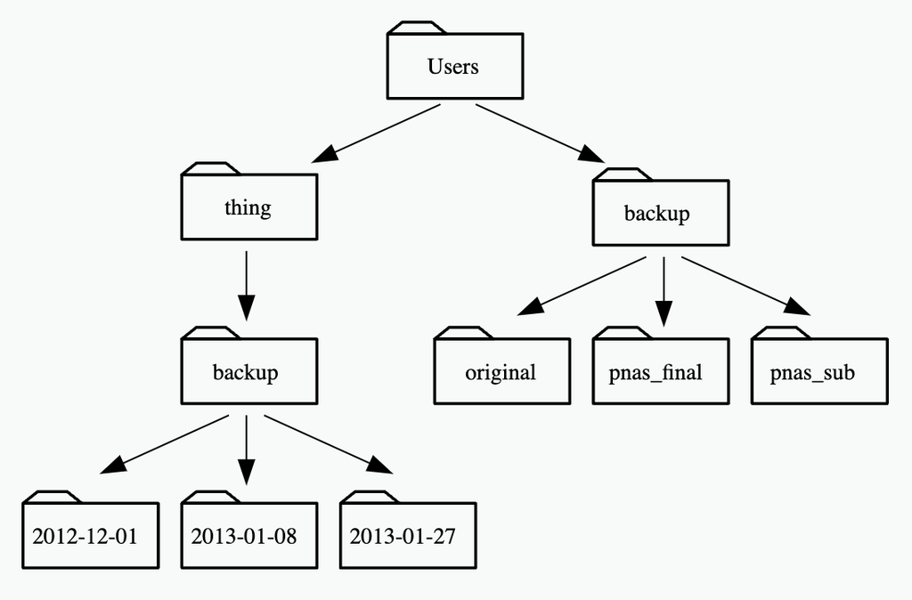

# 2. Navigating files and directories (continued)

General syntax of the shell command

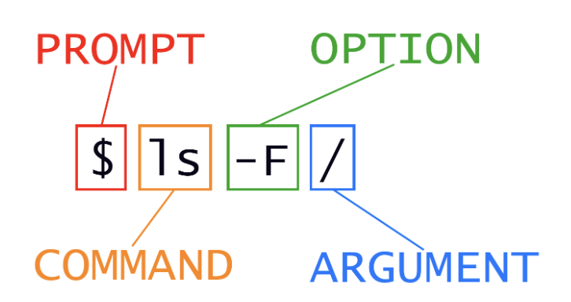

# 3. Working With Files and Directories

- Create a directory using the mkdir command

```bash
mkdir -p thesis
```

# 3. Working With Files and Directories (continued)

```bash
ls -F -a
```

```
## ./
## ../
## .DS_Store
## .Rhistory
## Introduction to R and Terminal.Rmd
## Introduction to the Terminal.Rmd
## Introduction-to-R-and-Terminal.html
## Introduction-to-the-Terminal.Rmd
## Introduction-to-the-Terminal.html
## test folder/
## thesis/
```

# 3. Working With Files and Directories (continued)

- Let’s check what is the current directory and change our working directory to test using cd
- Then run a text editor called Touch to create a file called draft.txt.
- Finally, we will check that we created the file with the ls command:

# 3. Working With Files and Directories (continued)

```bash
pwd
cd thesis
touch draft.txt
ls
```

```
## /Users/gepolianochaves/Desktop/Gepoliano/SIP2023_BME03/recombio/1-Introduction/scripts
## draft.txt
```

# 3. Working With Files and Directories (continued)

- Let’s go back to the scripts folder

```bash
# check the current directory
pwd
# change to the test directory
cd ./thesis
# check the current directory
pwd
# change to the scripts directory
cd ../
# check the current directory
pwd
```

```
## /Users/gepolianochaves/Desktop/Gepoliano/SIP2023_BME03/recombio/1-Introduction/scripts
## /Users/gepolianochaves/Desktop/Gepoliano/SIP2023_BME03/recombio/1-Introduction/scripts/thesis
## /Users/gepolianochaves/Desktop/Gepoliano/SIP2023_BME03/recombio/1-Introduction/scripts
```

# 3. Working With Files and Directories (continued)

```bash
# check the current directory
pwd
# Move draft.txt to current directory
mv ./thesis/draft.txt ./
# List current directory
ls
# Move draft.txt back to ./thesis
mv draft.txt ./thesis/
# change to thesis directory
cd ./thesis
# List current directory and confirm draft there
ls
```

```
## /Users/gepolianochaves/Desktop/Gepoliano/SIP2023_BME03/recombio/1-Introduction/scripts
## Introduction to R and Terminal.Rmd
## Introduction to the Terminal.Rmd
## Introduction-to-R-and-Terminal.html
## Introduction-to-the-Terminal.Rmd
## Introduction-to-the-Terminal.html
## draft.txt
## test folder
## thesis
## draft.txt
```

# 3. Working With Files and Directories (continued)

- Removing files and directories

```bash
ls ./thesis/draft.txt
rm ./thesis/draft.txt
ls ./thesis/draft.txt
ls ./thesis/
du -sh ./thesis/
```

```
## ./thesis/draft.txt
## ls: ./thesis/draft.txt: No such file or directory
##   0B ./thesis/
```

# 3. Working With Files and Directories (continued)

- Removing the thesis directory

```bash
ls
echo "Not using the -r option:"
rm thesis
ls
```

```
## Introduction to R and Terminal.Rmd
## Introduction to the Terminal.Rmd
## Introduction-to-R-and-Terminal.html
## Introduction-to-the-Terminal.Rmd
## Introduction-to-the-Terminal.html
## test folder
## thesis
## Not using the -r option:
## rm: thesis: is a directory
## Introduction to R and Terminal.Rmd
## Introduction to the Terminal.Rmd
## Introduction-to-R-and-Terminal.html
## Introduction-to-the-Terminal.Rmd
## Introduction-to-the-Terminal.html
## test folder
## thesis
```

# 3. Working With Files and Directories (continued)

```bash
ls
echo "Using the -r option:"
rm -r thesis
ls
```

```
## Introduction to R and Terminal.Rmd
## Introduction to the Terminal.Rmd
## Introduction-to-R-and-Terminal.html
## Introduction-to-the-Terminal.Rmd
## Introduction-to-the-Terminal.html
## test folder
## thesis
## Using the -r option:
## Introduction to R and Terminal.Rmd
## Introduction to the Terminal.Rmd
## Introduction-to-R-and-Terminal.html
## Introduction-to-the-Terminal.Rmd
## Introduction-to-the-Terminal.html
## test folder
```

# 4. Pipes and Filters

- wc counts lines, words, and characters in its inputs.
- cat displays the contents of its inputs.
- sort sorts its inputs.
- head displays the first 10 lines of its input.

# 4. Pipes and Filters (continued)

- tail displays the last 10 lines of its input.
- command > [file] redirects a command’s output to a file (overwriting any existing content).
- command >> [file] appends a command’s output to a file.
- [first] | [second] is a pipeline: the output of the first command is used as the input to the second.
- The best way to use the shell is to use pipes to combine simple single-purpose programs (filters).

# 5. Loops

# 5. Loops (continued)

- Print the names of every FASTA file.

```bash
cd ../../2-Variant-Call-Pipeline/regions/brazil/2020/fasta
for i in Brazil*; do echo $i; done
```

```
## Brazil_2020_07_01-2020_12_31_1.fasta
## Brazil_2020_07_01-2020_12_31_10.fasta
## Brazil_2020_07_01-2020_12_31_100.fasta
## Brazil_2020_07_01-2020_12_31_101.fasta
## Brazil_2020_07_01-2020_12_31_102.fasta
## Brazil_2020_07_01-2020_12_31_103.fasta
## Brazil_2020_07_01-2020_12_31_104.fasta
## Brazil_2020_07_01-2020_12_31_105.fasta
## Brazil_2020_07_01-2020_12_31_106.fasta
## Brazil_2020_07_01-2020_12_31_107.fasta
## Brazil_2020_07_01-2020_12_31_108.fasta
## Brazil_2020_07_01-2020_12_31_109.fasta
## Brazil_2020_07_01-2020_12_31_11.fasta
## Brazil_2020_07_01-2020_12_31_110.fasta
## Brazil_2020_07_01-2020_12_31_111.fasta
## Brazil_2020_07_01-2020_12_31_112.fasta
## Brazil_2020_07_01-2020_12_31_113.fasta
## Brazil_2020_07_01-2020_12_31_114.fasta
## Brazil_2020_07_01-2020_12_31_115.fasta
## Brazil_2020_07_01-2020_12_31_116.fasta
## Brazil_2020_07_01-2020_12_31_117.fasta
## Brazil_2020_07_01-2020_12_31_118.fasta
## Brazil_2020_07_01-2020_12_31_119.fasta
## Brazil_2020_07_01-2020_12_31_12.fasta
## Brazil_2020_07_01-2020_12_31_120.fasta
## Brazil_2020_07_01-2020_12_31_121.fasta
## Brazil_2020_07_01-2020_12_31_122.fasta
## Brazil_2020_07_01-2020_12_31_123.fasta
## Brazil_2020_07_01-2020_12_31_124.fasta
## Brazil_2020_07_01-2020_12_31_125.fasta
## Brazil_2020_07_01-2020_12_31_126.fasta
## Brazil_2020_07_01-2020_12_31_127.fasta
## Brazil_2020_07_01-2020_12_31_128.fasta
## Brazil_2020_07_01-2020_12_31_129.fasta
## Brazil_2020_07_01-2020_12_31_13.fasta
## Brazil_2020_07_01-2020_12_31_130.fasta
## Brazil_2020_07_01-2020_12_31_131.fasta
## Brazil_2020_07_01-2020_12_31_132.fasta
## Brazil_2020_07_01-2020_12_31_133.fasta
## Brazil_2020_07_01-2020_12_31_134.fasta
```

[output cut: 195 more lines]

```
## Brazil_2020_07_01-2020_12_31_86.fasta
## Brazil_2020_07_01-2020_12_31_87.fasta
## Brazil_2020_07_01-2020_12_31_88.fasta
## Brazil_2020_07_01-2020_12_31_89.fasta
## Brazil_2020_07_01-2020_12_31_9.fasta
## Brazil_2020_07_01-2020_12_31_90.fasta
## Brazil_2020_07_01-2020_12_31_91.fasta
## Brazil_2020_07_01-2020_12_31_92.fasta
## Brazil_2020_07_01-2020_12_31_93.fasta
## Brazil_2020_07_01-2020_12_31_94.fasta
## Brazil_2020_07_01-2020_12_31_95.fasta
## Brazil_2020_07_01-2020_12_31_96.fasta
## Brazil_2020_07_01-2020_12_31_97.fasta
## Brazil_2020_07_01-2020_12_31_98.fasta
## Brazil_2020_07_01-2020_12_31_99.fasta
```

# 5. Loops (continued)

- Let’s pipe this output into the wc command and let’s have it count how many files, for us.

```bash
cd ../../2-Variant-Call-Pipeline/regions/brazil/2020/fasta
for i in Brazil*; do echo $i; done | wc
```

```
##      250     250    9642
```

- Now count only the number of lines

```bash
cd ../../2-Variant-Call-Pipeline/regions/brazil/2020/fasta
for i in Brazil*; do echo $i; done | wc -l
```

```
##      250
```

# 6. Shell Scripts

- Variant call shell script: an alignment in a **for loop**

```bash
Region=brazil

for fasta_file in $(cat brazil_fasta_julDec/COVID_List_Region.txt); do

  ## Print names of Project Directory and FASTA file
  echo $ProjectDirectory
  echo $fast_file


  ## Alignment
  ~/anaconda3/bin/bwa mem -M -R \
  '@RG\tID:SampleCorona\tLB:sample_1\tPL:ILLUMINA\tPM:HISEQ\tSM:SampleCorona' \
  fasta_reference_file/SARS-CoV-2.fasta \
  brazil_fasta_julDec/$fasta_file > \
  brazil_alignment_julDec_sam/$fasta_file".sam"


  ## SAM to BAM
  samtools view -S -b $Region"_alignment_julDec_sam"/$fasta_file".sam" > \
  $Region"_alignment_julDec_bam"/$fasta_file".bam"


  ## Samtools uses reference FASTA to detect "piles" in the alignment
  samtools mpileup -g -f fasta_reference_file/SARS-CoV-2.fasta $Region"_alignment_julDec_bam"/$fasta_file".bam" > \
  $Region"_julDec_bcf"/$fasta_file".bcf"

  ## Bcftools extracts SNPs
  ~/Desktop/Gepoliano/bcftools/bcftools view -v snps $Region"_julDec_bcf"/$fasta_file".bcf" > $Region"_vcf_julDec_snp"/$fasta_file"_snps.vcf"

  ## Bcftools extracts indels
  ~/Desktop/Gepoliano/bcftools/bcftools view -v indels $Region"_julDec_bcf"/$fasta_file".bcf" > $Region"_vcf_julDec_indel"/$fasta_file"_indels.vcf"

done
```

# 7. Finding Things

- The find command

```bash
pwd
find . -name "*Rmd" -print
```

```
## /Users/gepolianochaves/Desktop/Gepoliano/SIP2023_BME03/recombio/1-Introduction/scripts
## ./Introduction to the Terminal.Rmd
## ./Introduction-to-the-Terminal.Rmd
## ./Introduction to R and Terminal.Rmd
```

- find names of figures of format png

```bash
pwd
find ../figures -name "*png" -print
```

```
## /Users/gepolianochaves/Desktop/Gepoliano/SIP2023_BME03/recombio/1-Introduction/scripts
## ../figures/general syntax.png
## ../figures/absolute vs relative paths.png
```

# 7. Finding Things (continued)

- The grep command

```bash
grep "print" Introduction\ to\ the\ Terminal.Rmd
```

```
##   #   df_print: paged
## print working directory
## find . -name "*Rmd" -print
## find ../figures -name "*png" -print
## grep "print" Introduction\ to\ the\ Terminal.Rmd
```

# 7. Finding Things (continued)

- The cat and head commands

```bash
cat Introduction\ to\ the\ Terminal.Rmd | head
```

```
## ---
## title: "Introduction to the Command Line (Terminal)"
## author: "Gepoliano Chaves, Ph. D."
## date: "September 9th, 2023"
## output:
##   # pdf_document: default
##   # output: slidy_presentation
##   revealjs::revealjs_presentation
##   # html_document:
##   #   df_print: paged
```

# 8) References